# Class activity: Visualization and Data Understanding

Josep Ramon Ribera

### Step 1: Load in R the dataset “tv.txt”

```r
tv_data = read.table("tv.txt", header = TRUE)
```

TV Data Table

| tvhours | obedience | attitude |
| --- | --- | --- |
| 3 | 1 | 2 |
| 1 | 1 | 1 |
| 4 | 1 | 1 |
| 4 | 1 | 1 |
| 7 | 1 | 1 |
| 2 | 1 | 1 |
| 7 | 1 | 1 |
| 14 | 1 | 3 |
| 3 | 1 | 1 |
| 3 | 2 | 2 |
| 2 | 2 | 2 |
| 3 | 3 | 2 |
| 3 | 3 | 2 |
| 5 | 2 | 2 |
| 5 | 1 | 2 |
| 2 | 2 | 1 |
| 2 | 1 | 1 |
| 2 | 1 | 1 |
| 2 | 1 | 1 |
| 2 | 3 | 2 |
| 2 | 2 | 2 |
| 4 | 2 | 2 |
| 3 | 2 | 2 |
| 10 | 1 | 2 |
| 4 | 1 | 1 |
| 10 | 1 | 2 |
| 2 | 1 | 1 |
| 2 | 1 | 2 |
| 4 | 1 | 1 |
| 4 | 1 | 1 |

### Step 2: Answer the following questions:

#### 1. How many hours a day on average does each child watch television? What is the range of TV hours watched?

```r
tvhours_avg = mean(tv_data$tvhours)
```

```
## [1] 4.033333
```

```r
tvhours_range = range(tv_data$tvhours)
```

```
## [1]  1 14
```

On average, each child watches TV approximately 4 hours a day. The hour range of all children is between 1 and 14

#### 2. When calculating the average number of hours of television watched, was there any apparent outlier? What effect could this have on the mean?

```r
outliers = boxplot.stats(tv_data$tvhours)$out
```

```
## [1] 14 10 10
```

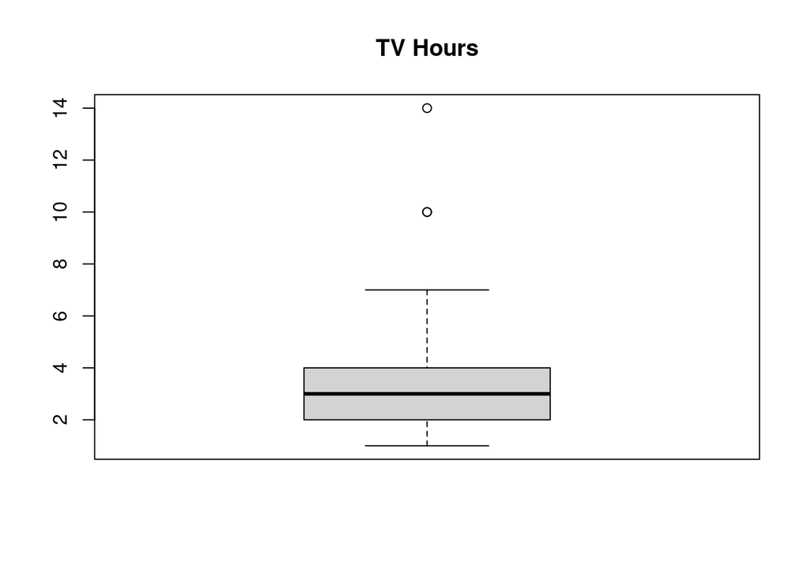

```r
boxplot(tv_data$tvhours, main = "TV Hours")
```

As we can see, there are 3 data that are outliers: 10, 10 and 14.

These values can distort the mean, in this case making it significantly larger.

#### 3. Recompute the mean without the outlier(s) and remove them from the original dataframe.

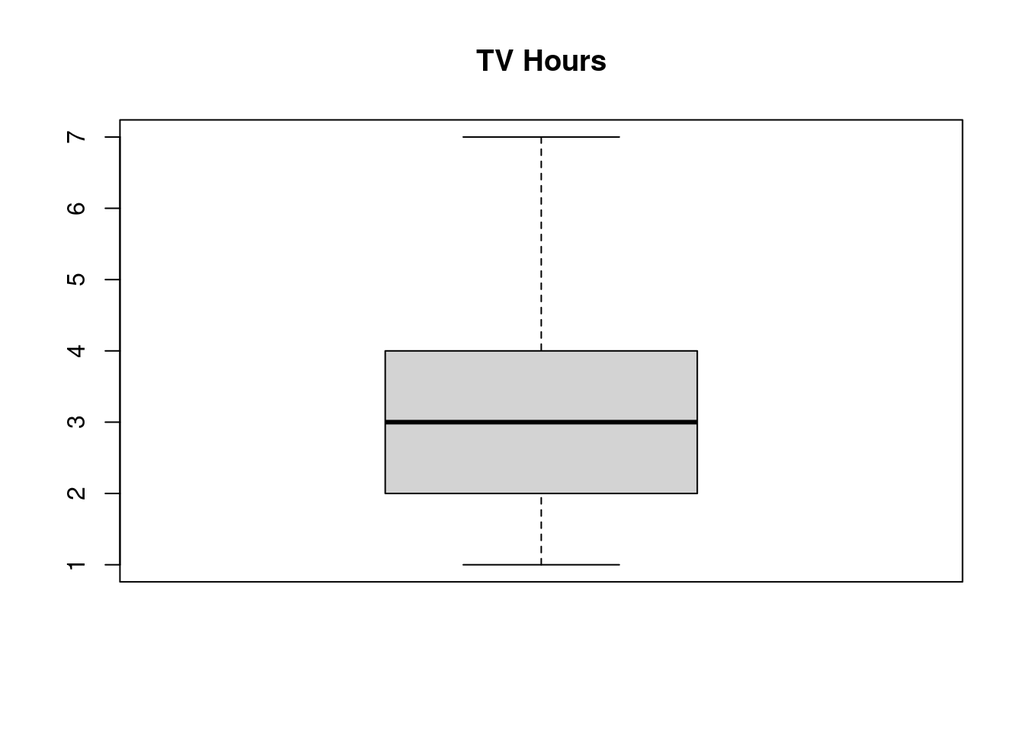

```r
tv_data = tv_data[!tv_data$tvhours %in% outliers, ]
boxplot(tv_data$tvhours, main = "TV Hours")
```

```r
tvhours_avg = mean(tv_data$tvhours)
```

```
## [1] 3.222222
```

We can see that the value of the mean has decreased considerably

#### 4. What is the overall correlation between the numbers of TV hours watched and the obedience? What is the correlation between TV hours watched and attitude?

```r
cor_tvhours_obedience = cor(tv_data$tvhours, tv_data$obedience)
```

```
## [1] -0.1788204
```

```r
cor_tvhours_attitude = cor(tv_data$tvhours, tv_data$attitude)
```

```
## [1] -0.08427498
```

We observe that the correlation of hours of television with obedience is -0.1788204, and with attitude is -0.08427498

#### 5. Describe the relationships indicated in question 4. Are any of these correlations statistically significant?

```r
cor.test(tv_data$tvhours, tv_data$obedience)
```

```
##
##  Pearson's product-moment correlation
##
## data:  tv_data$tvhours and tv_data$obedience
## t = -0.90875, df = 25, p-value = 0.3722
## alternative hypothesis: true correlation is not equal to 0
## 95 percent confidence interval:
##  -0.5232756  0.2158623
## sample estimates:
##        cor
## -0.1788204
```

As indicated by the Pearson correlation coefficient, the value -0.17 reveals a weak negative correlation. That is, as hours of television increase, obedience slightly tends to decrease, however the relationship is weak.

Furthermore, the p-value indicates that the correlation is not statistically significant, since it is much greater than 0.05.

```r
cor.test(tv_data$tvhours, tv_data$attitude)
```

```
##
##  Pearson's product-moment correlation
##
## data:  tv_data$tvhours and tv_data$attitude
## t = -0.42288, df = 25, p-value = 0.676
## alternative hypothesis: true correlation is not equal to 0
## 95 percent confidence interval:
##  -0.4498812  0.3055236
## sample estimates:
##         cor
## -0.08427498
```

Here we also observe that the Pearson correlation coefficient indicates an even lower negative correlation.

Also the p-value is still very high at 0.05, so the correlation is not statistically significant.

#### 6. Do a simple frequency count on attitude. What fundamental problem does this data present for the hypothesis? What sampling changes could be made to better test the hypothesis that “children who watch more hours of TV are more aggressive”?

```r
frequency_count_attitude = table(tv_data$attitude)
```

```
##
##  1  2
## 15 12
```

The attitude variable only appears in two possible values. Since the range of values is from 1 to 5, it indicates that our sample is not sufficiently diversified. To solve this problem, we should not only increase the sample, but also look for more profiles to add diversity to the data set.

In this case a stratified sampling (children from different socioeconomic backgrounds) could ensure that all relevant groups are adequately represented.